# CRAN

Most recent datum: **Sep 18, 2026**Page built on Sep 19, 2026, 11:30 UTC. Every figure below is dated by its data, never by this build.

Check status by package and flavour, the daily download sample with release markers, and the complete version history.

## Package status

Snapshot of Sep 19, 2026

| Package | Worst status | Flavours checked | Flavours outside OK | On CRAN | Archived | Maintainer |
| --- | --- | --- | --- | --- | --- | --- |
| betaregscale | ✓OK, check status: check passed on every flavour | 13 | 0 | yes | no | José Evandeilton Lopes |
| gkwdist | ✓OK, check status: check passed on every flavour | 13 | 0 | yes | no | José Evandeilton Lopes |
| gkwreg | ✓OK, check status: check passed on every flavour | 13 | 0 | yes | no | José Evandeilton Lopes |
| OptimalBinningWoE | ✓OK, check status: check passed on every flavour | 13 | 0 | yes | no | José Evandeilton Lopes |

## Check status by package and flavour

One column per CRAN check flavour, latest snapshot only. Status is given as text, never by colour alone.

Snapshot of Sep 19, 2026

| Flavour | betaregscale | gkwdist | gkwreg | OptimalBinningWoE |
| --- | --- | --- | --- | --- |
| r-devel-linux-x86_64-debian-clang | ✓OK, check status: check passed on every flavour | ✓OK, check status: check passed on every flavour | ✓OK, check status: check passed on every flavour | ✓OK, check status: check passed on every flavour |
| r-devel-linux-x86_64-debian-gcc | ✓OK, check status: check passed on every flavour | ✓OK, check status: check passed on every flavour | ✓OK, check status: check passed on every flavour | ✓OK, check status: check passed on every flavour |
| r-devel-linux-x86_64-fedora-clang | ✓OK, check status: check passed on every flavour | ✓OK, check status: check passed on every flavour | ✓OK, check status: check passed on every flavour | ✓OK, check status: check passed on every flavour |
| r-devel-linux-x86_64-fedora-gcc | ✓OK, check status: check passed on every flavour | ✓OK, check status: check passed on every flavour | ✓OK, check status: check passed on every flavour | ✓OK, check status: check passed on every flavour |
| r-devel-windows-x86_64 | ✓OK, check status: check passed on every flavour | ✓OK, check status: check passed on every flavour | ✓OK, check status: check passed on every flavour | ✓OK, check status: check passed on every flavour |
| r-oldrel-macos-arm64 | ✓OK, check status: check passed on every flavour | ✓OK, check status: check passed on every flavour | ✓OK, check status: check passed on every flavour | ✓OK, check status: check passed on every flavour |
| r-oldrel-macos-x86_64 | ✓OK, check status: check passed on every flavour | ✓OK, check status: check passed on every flavour | ✓OK, check status: check passed on every flavour | ✓OK, check status: check passed on every flavour |
| r-oldrel-windows-x86_64 | ✓OK, check status: check passed on every flavour | ✓OK, check status: check passed on every flavour | ✓OK, check status: check passed on every flavour | ✓OK, check status: check passed on every flavour |
| r-patched-linux-x86_64 | ✓OK, check status: check passed on every flavour | ✓OK, check status: check passed on every flavour | ✓OK, check status: check passed on every flavour | ✓OK, check status: check passed on every flavour |
| r-release-linux-x86_64 | ✓OK, check status: check passed on every flavour | ✓OK, check status: check passed on every flavour | ✓OK, check status: check passed on every flavour | ✓OK, check status: check passed on every flavour |
| r-release-macos-arm64 | ✓OK, check status: check passed on every flavour | ✓OK, check status: check passed on every flavour | ✓OK, check status: check passed on every flavour | ✓OK, check status: check passed on every flavour |
| r-release-macos-x86_64 | ✓OK, check status: check passed on every flavour | ✓OK, check status: check passed on every flavour | ✓OK, check status: check passed on every flavour | ✓OK, check status: check passed on every flavour |
| r-release-windows-x86_64 | ✓OK, check status: check passed on every flavour | ✓OK, check status: check passed on every flavour | ✓OK, check status: check passed on every flavour | ✓OK, check status: check passed on every flavour |

Check time (s)

| Package | Version | Check time (s) |
| --- | --- | --- |
| betaregscale | 2.7.4 | 175.5 |
| gkwdist | 1.1.5 | 129.4 |
| gkwreg | 2.1.18 | 180.0 |
| OptimalBinningWoE | 1.13.5 | 181.7 |

## Daily downloads

ⓘ **downloads from the Posit mirror (partial sample)**. Why this is a partial sample and not a download total.

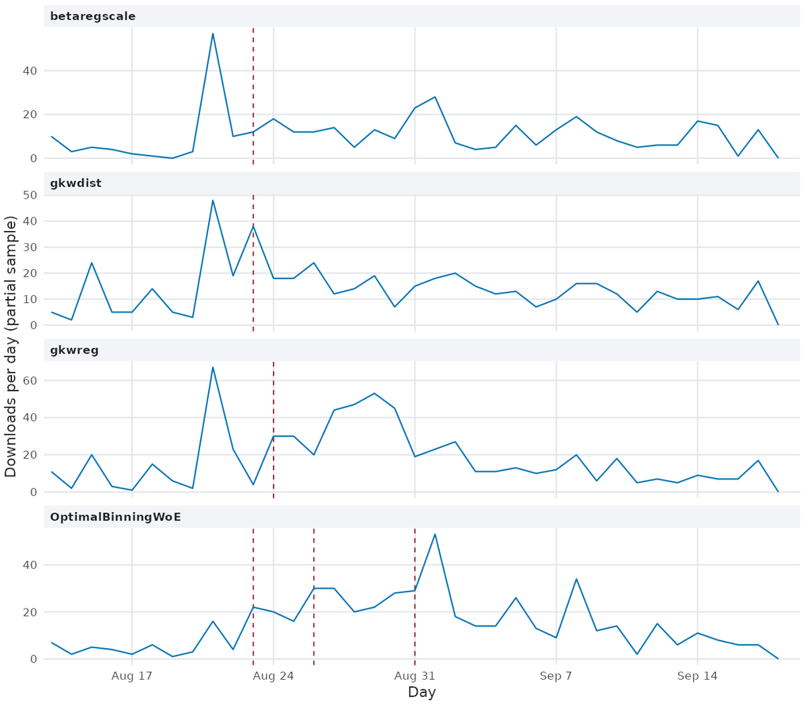

Chart data up to Sep 18, 2026. Exported window: Sep 19, 2025 to Sep 18, 2026.

Download sample per package — downloads from the Posit mirror (partial sample)

| Package | Downloads |
| --- | --- |
| betaregscale | 393 |
| gkwdist | 506 |
| gkwreg | 650 |
| OptimalBinningWoE | 528 |

## Permanent monthly archive

Monthly rollup, kept indefinitely. The daily series above is pruned to a rolling 12-month window.

ⓘ **downloads from the Posit mirror (partial sample)**. Why this is a partial sample and not a download total.

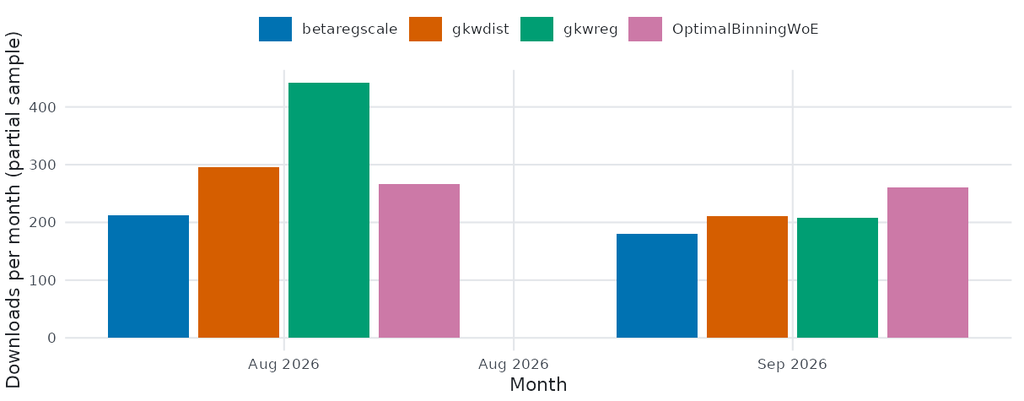

Permanent monthly archive — downloads from the Posit mirror (partial sample)

| Month | Package | Downloads |
| --- | --- | --- |
| Aug 2026 | betaregscale | 213 |
| Aug 2026 | gkwdist | 295 |
| Aug 2026 | gkwreg | 442 |
| Aug 2026 | OptimalBinningWoE | 267 |
| Sep 2026 | betaregscale | 180 |
| Sep 2026 | gkwdist | 211 |
| Sep 2026 | gkwreg | 208 |
| Sep 2026 | OptimalBinningWoE | 261 |

## Version history

Permanent table: every version published to CRAN, newest first.

| Package | Version | Release date | Current |
| --- | --- | --- | --- |
| OptimalBinningWoE | 1.13.5 | Aug 31, 2026 | yes |
| OptimalBinningWoE | 1.13.4 | Aug 26, 2026 | no |
| OptimalBinningWoE | 1.13.3 | Aug 23, 2026 | no |
| OptimalBinningWoE | 1.0.8 | Jan 29, 2026 | no |
| OptimalBinningWoE | 1.0.3 | Jan 23, 2026 | no |
| betaregscale | 2.7.4 | Aug 23, 2026 | yes |
| betaregscale | 2.6.9 | Feb 25, 2026 | no |
| gkwdist | 1.1.5 | Aug 23, 2026 | yes |
| gkwdist | 1.1.4 | May 28, 2026 | no |
| gkwdist | 1.1.3 | May 21, 2026 | no |
| gkwdist | 1.1.2 | Jan 8, 2026 | no |
| gkwdist | 1.1.1 | Nov 27, 2025 | no |
| gkwdist | 1.0.10 | Nov 13, 2025 | no |
| gkwreg | 2.1.18 | Aug 24, 2026 | yes |
| gkwreg | 2.1.14 | Jan 9, 2026 | no |
| gkwreg | 2.1.6 | Nov 27, 2025 | no |
| gkwreg | 2.1.1 | Nov 15, 2025 | no |
| gkwreg | 1.0.10 | Jul 9, 2025 | no |
| gkwreg | 1.0.7 | May 1, 2025 | no |
| gkwreg | 1.0.3 | Apr 15, 2025 | no |